# Probability and Statistics

# Lab Assignment 1: Naive Bayes Classifier

### Nazar Kononenko, Anna Polova, Natalia Chaika

## Introduction

During the past three weeks, you learned a couple of essential notions and theorems, and one of the most important among them is the *Bayes theorem*.

One of its applications is **Naive Bayes classifier**, which is a probabilistic classifier whose aim is to determine which class some observation probably belongs to by using the Bayes formula:
$$\mathsf{P}(\mathrm{class}\mid
\mathrm{observation})=\frac{\mathsf{P}(\mathrm{observation}\mid\mathrm{class})\mathsf{P}(\mathrm{class})}{\mathsf{P}(\mathrm{observation})}$$

Under the strong independence assumption, one can calculate $\mathsf{P}(\mathrm{observation} \mid \mathrm{class})$ as
$$\mathsf{P}(\mathrm{observation}) =
\prod_{i=1}^{n} \mathsf{P}(\mathrm{feature}_i), \qquad
\mathsf{P}(\mathrm{observation} \mid \mathrm{class}) = \prod_{i=1}^{n}
\mathsf{P}(\mathrm{feature}_i \mid \mathrm{class}),$$
where $n$ is the total number of features describing a given observation. Thus, $\mathsf{P}(\mathrm{class}|\mathrm{observation})$ now can be calculated as

$$\mathsf{P}(\mathrm{class} \mid
\mathrm{\mathrm{observation}}) = \mathsf{P}(\mathrm{class})\times
\prod_{i=1}^{n}\frac{\mathsf{P}(\mathrm{feature}_i\mid
\mathrm{class})}{\mathsf{P}(\mathrm{feature}_i)}\tag{1}$$

All the terms on the right-hand side can be estimated from the data as respective relative frequencies;  
see [this site](https://monkeylearn.com/blog/practical-explanation-naive-bayes-classifier/) for more detailed explanations.

## Data description

There are 5 datasets uploaded on the cms.

To determine your variant, take your team number from the list of teams on cms and take *mod 5* - this is the number of your data set.

- **0 - authors** This data set consists of citations of three famous writers: Edgar Alan Poe, Mary Wollstonecraft Shelley and HP Lovecraft. The task with this data set is to classify a piece of text with the author who was more likely to write it.
- **1 - discrimination** This data set consists of tweets that have discriminatory (sexism or racism) messages or of tweets that are of neutral mood. The task is to determine whether a given tweet has discriminatory mood or does not.
- **2 - fake news** This data set contains data of American news: a headline and an abstract of the article. Each piece of news is classified as fake or credible. The task is to classify the news from test.csv as credible or fake.
- **3 - sentiment** All the text messages contained in this data set are labeled with three sentiments: positive, neutral or negative. The task is to classify some text message as the one of positive mood, negative or neutral.
- **4 - spam** This last data set contains SMS messages classified as spam or non-spam (ham in the data set). The task is to determine whether a given message is spam or non-spam.

Each data set consists of two files: *train.csv* and *test.csv*. The first one you will need find the probabilities distributions for each of the features, while the second one is needed for checking how well your classifier works.

```r
# here goes a list of recommended libraries,
# though you may install other ones if they are needed
library(tidytext)
library(tidyverse)
library(readr)
library(dplyr)
library(r2r)
library(tidyr)
library(stringr)
library(rlist)
library(pipeR)
library(caret)
library(cvms)
library(ggimage)
```

## Instructions

- The first step is data pre-processing, which includes removing punctuation marks and stop words
- represent each message as a bag-of-words
- using the training set, calculate all the conditional probabilities in formula (1)
- use those to predict classes for messages in the test set
- evaluate effectiveness of the classifier by calculating the corresponding metrics
- shortly summarize your work
- do not forget to submit both the (compiled) Rmd source file and the .html output

### Data pre-processing

- Read the *.csv* data files.
- Сlear your data from punctuation or other unneeded symbols.
- Clear you data from stop words. You don’t want words as is, and, or etc. to affect your probabilities distributions, so it is a wise decision to get rid of them. Find list of stop words in the cms under the lab task.
- Represent each test message as its bag-of-words. Here: https://machinelearningmastery.com/gentle-introduction-bag-words-model/ you can find general introduction to the bag-of-words model and examples on to create it.
- It is highly recommended to get familiar with R dataframes, it would make the work much easier to do.
- Useful links:
  - https://steviep42.github.io/webscraping/book/bagofwords.html#tidytext - example of using *tidytext* to count frequencies of the words.
  - Basics of Text Mining in R: http://rstudio-pubs-static.s3.amazonaws.com/256588_57b585da6c054349825cba46685d8464.html . Note that it also includes an example on how to create a bag of words from your text document.

```r
list.files(getwd())
```

```
## [1] "data"
## [2] "intro-R.Rmd"
## [3] "Lab1_Naive_Bayes_Classifier_Templatee.html"
## [4] "Lab1_Naive_Bayes_Classifier_Templatee.Rmd"
## [5] "Naive_bayers.Rproj"
## [6] "stop_words.txt"
```

```r
list.files("data/0-authors")
```

```
## [1] "test.csv"  "train.csv"
```

```r
test_path <- "data/0-authors/test.csv"
train_path <- "data/0-authors/train.csv"

stop_words <- read_file("stop_words.txt")
# https://stackoverflow.com/questions/27195912/why-does-strsplit-return-a-list
splitted_stop_words <- strsplit(stop_words, split='\n')
splitted_stop_words <- splitted_stop_words[[1]]
```

```r
train <-  read.csv(file = train_path, stringsAsFactors = FALSE)
test <-  read.csv(file = test_path, stringsAsFactors = FALSE)
```

```r
# note the power functional features of R bring us!
X = train[, -length(train)]
y = train[length(train)]

X_test = test[, -length(test)]
y_test = test[length(test)]
```

## Classifier implementation

```r
naiveBayes <- setRefClass("naiveBayes",

       # here it would be wise to have some vars to store intermediate result
       # frequency dict etc. Though pay attention to bag of wards!
       fields = list(
         tidy_X = "data.frame",
         author_count = "data.frame"
       ),
       methods = list(
                    # prepare your training data as X - bag of words for each of your
                    # messages and corresponding label for the message encoded as 0 or 1
                    # (binary classification task)
                    fit = function(X, y)
                    {
                      X = cbind(X, y)

                      tidy_X <<- unnest_tokens(X, 'splitted', 'text', token="words") %>%
                      filter(!splitted %in% splitted_stop_words)

                      author_count <<- y %>% count(author)

                      tidy_X <<- tidy_X %>%
                        count(splitted,sort=TRUE, author) %>%
                        pivot_wider(names_from=author, values_from=n)

                      tidy_X <<- data.frame(tidy_X[-c(1)], row.names = tidy_X$splitted) %>% replace(is.na(.), 0) + 1
                    },

                    # return prediction for a single message
                    predict = function(message)
                    {
                      result = c()

                      message = strsplit(message, "[[:punct:] ]")
                      message = tolower(message[[1]])

                      for (author in 1:3) {
                        author_probability = author_count[author,2] / sum(author_count[, "n"])
                        author_words_sum = sum(tidy_X[author])
                        message_prob = 1

                        for (idx in 1:length(message)) {

                          if (!(message[idx] %in% splitted_stop_words)) {
                            word_count <- tidy_X[message[idx], author]

                            if (!is.na(word_count)) {
                              message_prob = message_prob * (word_count / author_words_sum)
                            }
                          }
                        }

                        result = append(result, author_probability * message_prob)
                      }

                      return(which(result == max(result))[1])
                    },

                    # score you test set so to get the understanding how well you model
                    # works.
                    # look at f1 score or precision and recall
                    # visualize them
                    # try how well your model generalizes to real world data!
                    score = function(X_test, y_test)
                    {
                      columns = c("pred")
                      result = data.frame(matrix(nrow=length(X_test$text), ncol=1))
                      colnames(result) = columns

                      for (i in 1:3) {
                        y_test[y_test == author_count[i, 1]] = i
                      }

                      result["pred"] = apply(X_test["text"], 1, FUN=.self$predict)

                      y_test$author = as.factor(y_test$author)
                      result$pred = as.factor(result$pred)
                      return(confusionMatrix(y_test$author, result$pred))
                    },

                    visualize_matrix = function(confusion_matrix)
                    {
                      test_data_tible = as_tibble(confusion_matrix$table)
                      colnames(test_data_tible) = c("Target","Prediction","N")
                      plot_confusion_matrix(
                        test_data_tible,
                        add_sums=T,
                        sums_settings = sum_tile_settings(
                            palette = "Oranges",
                            label = "Total",
                            tc_tile_border_color = "black"
                        )
                    )
                    }
))

model2 = naiveBayes()
model2$fit(X, y)
confusion_matrix = model2$score(X_test, y_test)
print(confusion_matrix)
```

```
## Confusion Matrix and Statistics
##
##           Reference
## Prediction    1    2    3
##          1 1959  148  267
##          2  205 1336  120
##          3  174   78 1587
##
## Overall Statistics
##
##                Accuracy : 0.8311
##                  95% CI : (0.8213, 0.8406)
##     No Information Rate : 0.398
##     P-Value [Acc > NIR] : < 2.2e-16
##
##                   Kappa : 0.7436
##
##  Mcnemar's Test P-Value : 3.231e-08
##
## Statistics by Class:
##
##                      Class: 1 Class: 2 Class: 3
## Sensitivity            0.8379   0.8553   0.8040
## Specificity            0.8826   0.9246   0.9354
## Pos Pred Value         0.8252   0.8043   0.8630
## Neg Pred Value         0.8917   0.9464   0.9041
## Prevalence             0.3980   0.2659   0.3361
## Detection Rate         0.3335   0.2274   0.2702
## Detection Prevalence   0.4042   0.2828   0.3131
## Balanced Accuracy      0.8603   0.8900   0.8697
```

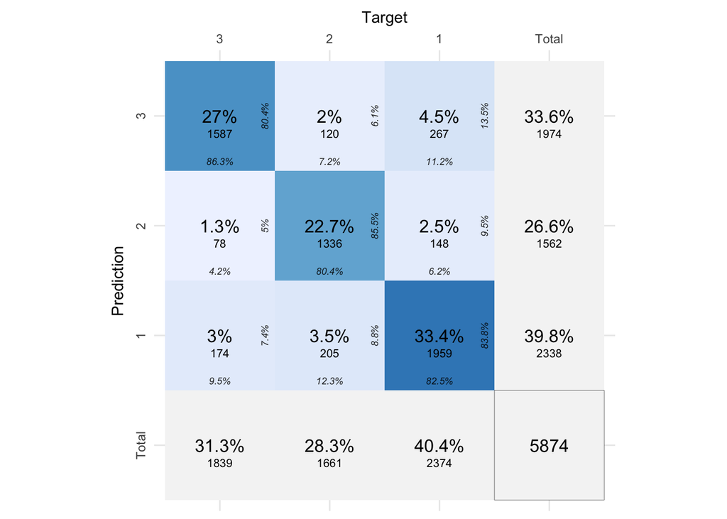

```r
model2$visualize_matrix(confusion_matrix)
```